# Wine Production — Exploratory Data Analysis

Douro (RDD) & Vinho Verde (RVV) | Climate × Yield Relationships

Hugo Nogueira

April 2026

# Overview

This notebook explores the **two wine production datasets** for the Douro (RDD) and Vinho Verde (RVV) demarcated regions. The dataset spans several decades of annual vine phenology and climate observations, linked to total wine production in million hectolitres (mhl).

# 1 Wine Production Over Time

## 1.1 Raw series and trend

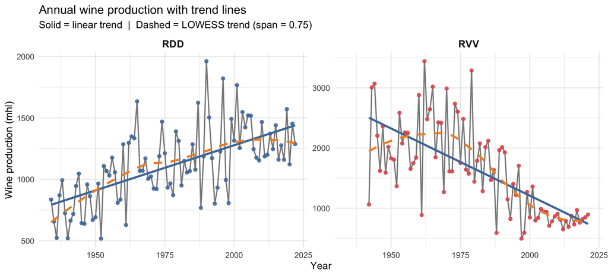

The two regions tell **opposite structural stories**. RDD shows a clear positive trend — production roughly doubling from the 1930s to the 2000s, consistent with vineyard expansion and modernisation of viticultural practices. RVV shows a strong negative trend, with production declining from the early decades to the present, likely reflecting regulatory changes in planted area and regional restructuring.

The linear and LOWESS fits agree well for RDD, suggesting a broadly linear trajectory. For RVV the picture is more nuanced: the LOWESS reveals a relatively stable plateau through the 1940s–1970s followed by a sharp decline from the 1980s onwards — a non-linearity that a single straight line cannot capture. This distinction matters for the detrending step: linear detrending is likely adequate for RDD, but may over-correct early RVV years and under-correct recent ones. The diagnostic tests in `detrend_diagnostics.R` will formalise this.

## 1.2 Decade-level averages

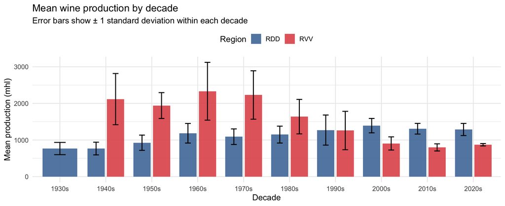

The decade breakdown confirms and sharpens the story from the raw trend. RDD grew steadily from roughly 800 mhl in the 1930s to around 1 200–1 400 mhl in the 2000s–2020s, with moderate and fairly stable within-decade variability throughout. RVV follows the opposite arc: peak production exceeding 2 000 mhl per decade in the 1940s–1970s, then a steep decline toward 800 mhl by the 2020s. Notably, the error bars for RVV are widest in the mid-century decades, suggesting that inter-annual climate variability had a greater influence on production during the high-output era — which makes the detrended residuals for that period especially informative.

## 1.3 Detrended residuals

After removing the long-term production trend (here: linear), the **residuals represent year-to-year climate-driven deviations**. This is the target variable used in the rule-learning pipeline. A residual near zero means production was as expected for that era; large positive/negative values indicate climate anomalies.

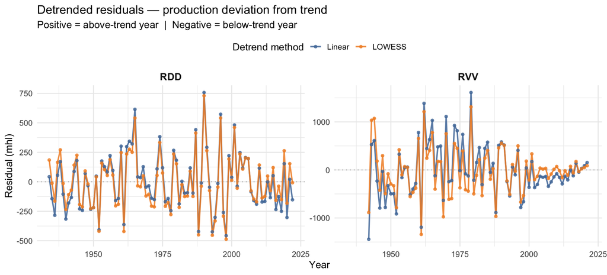

# 2 Phenological Event Timing

Vine phenology records the **day of the year (DOY)** on which key growth events occur: bud break, flowering, start of maturity, and harvest. These dates are direct outputs of the vine’s response to temperature accumulation — earlier dates signal warmer conditions, later dates signal cooler ones.

Crucially, the engineered climate features in the modelling dataset are computed as windows *centred on* or *around* these DOY events. Understanding how the phenological calendar itself has shifted is therefore both an agronomic story and a methodological one: if bud break is happening three weeks earlier than in 1950, then the climate conditions captured inside each phenological window are also shifting in calendar time.

## 2.1 Phenological dates over time

Each line traces the evolution of a phenological event’s day-of-year. A **downward trend** means the event is happening earlier — the most common fingerprint of warming temperatures.

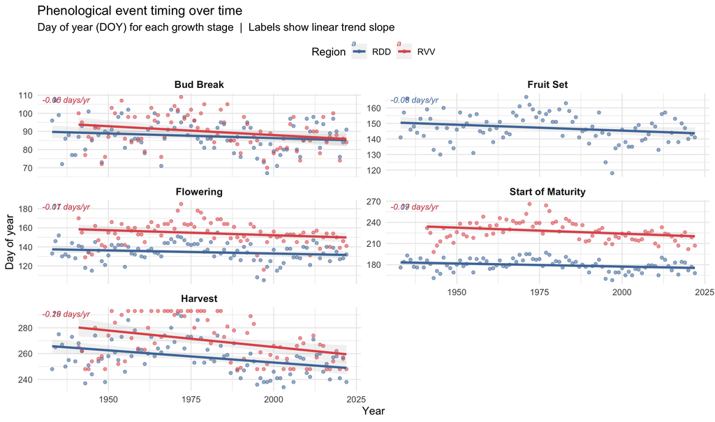

All five events are shifting earlier, consistently across both regions — a clear warming fingerprint, but the rate of advance is *not* uniform across the season. The strongest drift is at **Harvest** (RDD: −0.19 d/yr, p<0.001; RVV: −0.26 d/yr, p<0.001), followed by **Start of Maturity** (RDD: −0.09 d/yr, p=0.012; RVV: −0.17 d/yr, p=0.007). Earlier-season events drift more slowly: Fruit Set −0.08 d/yr (RDD only), Flowering −0.07 (RDD) / −0.11 (RVV), and Bud Break −0.05 (RDD) / −0.10 (RVV) — none of these reach the 0.05 significance level except RVV Bud Break (p=0.022). In other words, **the late-season warming signal is the dominant one**: harvest is moving forward faster than veraison, and veraison faster than flowering and bud break. This is precisely the pattern that drives the asymmetric phase-compression observed in §2.3, where the Start-of-Maturity → Harvest interval shortens significantly while Bud-Break → Flowering remains essentially flat. A consistent observation across all panels is that RVV events occur later in the calendar year than their RDD counterparts — reflecting RVV’s more northerly latitude, higher rainfall, and cooler Atlantic-influenced climate.

## 2.2 Decade-level distributions

Beyond the mean shift, are individual events also becoming *more variable* over time — indicating less predictable growing seasons?

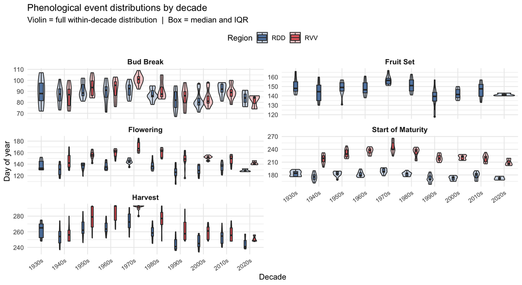

The decade-level violin plots confirm the directional shifts already seen in the trend lines, and add a distributional dimension. The leftward migration of median lines is visible across all events and both regions. For harvest in particular, the within-decade spread appears to narrow in recent decades — suggesting that harvest dates are becoming more consistent (less inter-annual variability), even as they shift earlier. Bud break shows the opposite in RVV: wider and more asymmetric distributions in mid-century decades, which may reflect that early bud break events were more erratic before the current warming regime stabilised.

## 2.3 Inter-stage durations (growing season structure)

The **duration between consecutive stages** captures how compressed or extended each phenological phase is in a given year. A shortening bud-break-to-harvest window suggests accelerated ripening — which affects berry composition and, ultimately, wine volume and quality.

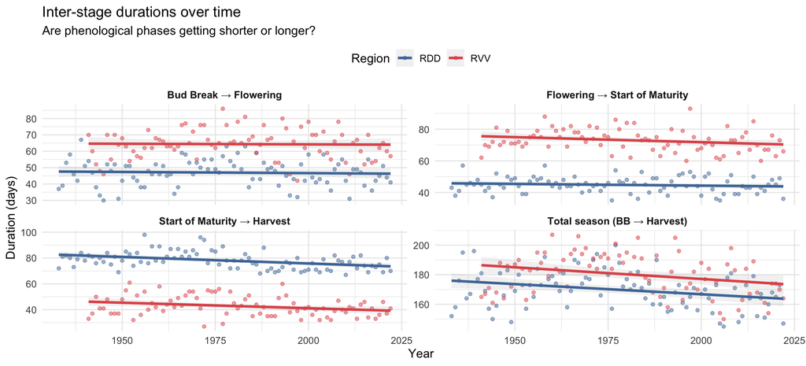

To quantify what the trend lines above suggest, we fit an ordinary least-squares regression `duration ~ year` for each region × phase, and report the slope as **days per decade** (slope × 10) together with its p-value (two-sided t-test of H₀: slope = 0) and R².

Linear trend in inter-stage duration over time, by region. Slopes are days per decade from an OLS fit of duration ~ year. Significance codes: *** p<0.001, ** p<0.01, * p<0.05, ns = not significant at α=0.05.

| Region | Phase | n | Mean (days) | Slope (d/decade) | p-value | R² | Sig |
| --- | --- | --- | --- | --- | --- | --- | --- |
| RDD | Bud Break → Flowering | 90 | 47.0 | -0.14 | 6.59e-01 | 0.002 | ns |
| RDD | Flowering → Start of Maturity | 90 | 44.8 | -0.22 | 2.80e-01 | 0.013 | ns |
| RDD | Start of Maturity → Harvest | 90 | 78.1 | -1.01 | 7.79e-05 | 0.163 | *** |
| RDD | Total season (BB → Harvest) | 90 | 169.9 | -1.37 | 6.75e-03 | 0.080 | ** |
| RVV | Bud Break → Flowering | 82 | 64.3 | -0.08 | 8.57e-01 | 0.000 | ns |
| RVV | Flowering → Start of Maturity | 82 | 73.0 | -0.64 | 4.55e-02 | 0.049 | * |
| RVV | Start of Maturity → Harvest | 82 | 42.7 | -0.86 | 1.61e-02 | 0.070 | * |
| RVV | Total season (BB → Harvest) | 82 | 180.0 | -1.58 | 1.36e-02 | 0.074 | * |

**Trend interpretation.** The total growing season (bud break to harvest) has shortened in both regions (RDD: −1.4 d/decade, p=0.007; RVV: −1.6 d/decade, p=0.014), but the compression is **not uniform across phases**. Contrary to what a casual reading of the trend lines might suggest, **Bud Break → Flowering is essentially stable** in both regions: slopes are within ±0.15 d/decade and not statistically distinguishable from zero (RDD p=0.66, RVV p=0.86). The contraction is concentrated in the **Start of Maturity → Harvest** phase, which shortens significantly in both RDD (−1.0 d/decade, p<0.001) and RVV (−0.9 d/decade, p=0.016). RVV additionally shows a mild contraction in **Flowering → Start of Maturity** (−0.6 d/decade, p=0.045) that RDD does not. In other words, vines in both regions reach bud-break-to-flowering in roughly the same time they always have, but **ripening (veraison-to-harvest) has accelerated** — consistent with warmer late-summer temperatures pushing harvests forward. This is the part of the season where the rule-learning pipeline is most likely to surface climate-driven signal.

## 2.4 Phenological timing vs wine production

Does an earlier harvest year correlate with higher or lower production? This scatter links the phenological signal directly to the modelling target.

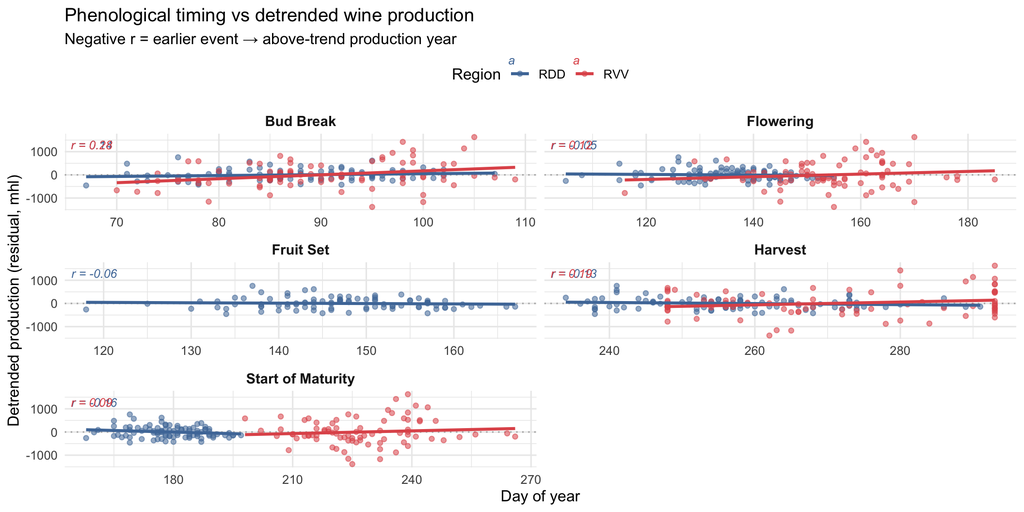

Correlations between phenological event timing and detrended production are generally weak (all |r| ≤ 0.31), which is an important negative result. The single strongest signal is for **Bud Break in RVV** (r = +0.31, p = 0.005): later bud break is associated with above-trend production. The biological intuition is that very early bud break exposes new shoots to late-frost risk, so years with somewhat later bud break may avoid frost damage and preserve yield potential. RDD shows a weaker, non-significant version of the same direction (r = +0.14, p = 0.19). All other events in both regions show correlations close to zero (|r| < 0.21). This tells us that the *timing* of phenological events per se is not strongly predictive of yield; what matters more are the *climate conditions within the windows around those events* — precisely what the engineered features in sections 3–5 are designed to capture.

# 3 Climate Feature Trends Over Time

## 3.1 Which features are drifting with time?

A feature that correlates strongly with *year* is itself trending — potentially confounded with the production trend. A high |correlation with year| also suggests a **climate change signal** in that variable, which is worth highlighting in the thesis.

| Feature | Stage | Cor (RDD) | Cor (RVV) |
| --- | --- | --- | --- |
| Tmean \| Harvest (curr yr) | hv | 0.373 | 0.335 |
| Tmean \| Harvest (curr yr) | hv | 0.412 | 0.229 |
| Tmean \| Harvest (prev yr) | hv | 0.371 | 0.263 |
| Tmean \| Start of Maturity (prev yr) | sm | 0.269 | 0.295 |
| Leaf Area Index \| Harvest (curr yr) | hv | 0.072 | 0.359 |
| Tmean \| Start of Maturity (curr yr) | sm | 0.017 | 0.402 |
| Wet days \| Harvest (curr yr) | hv | -0.178 | -0.239 |
| Tmean \| Start of Maturity (prev yr) | sm | 0.017 | 0.348 |
| Days Tmean<15°C \| Flowering (curr yr) | fl | -0.116 | -0.248 |
| Wet days \| Start of Maturity (curr yr) | sm | 0.199 | -0.125 |

[output cut: 10 more lines]

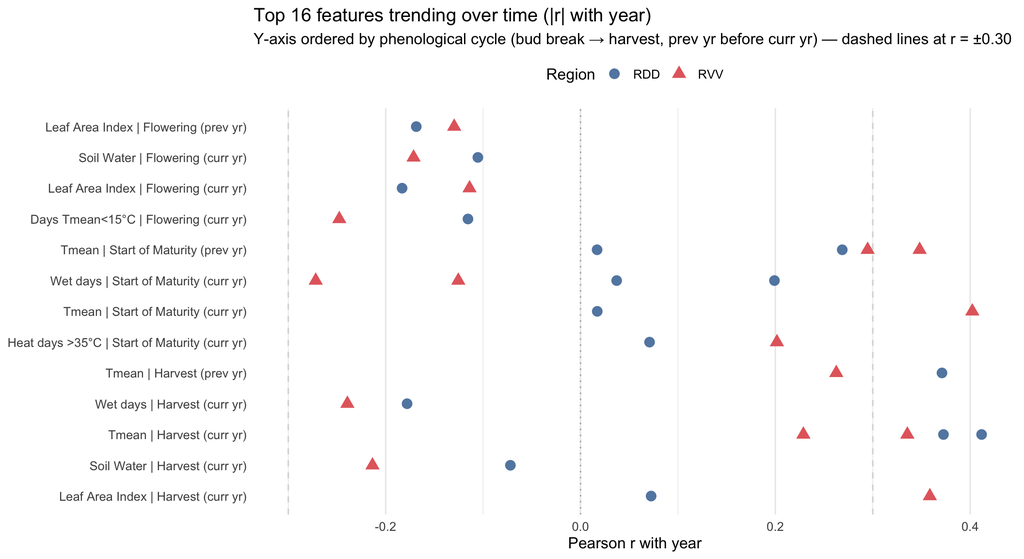

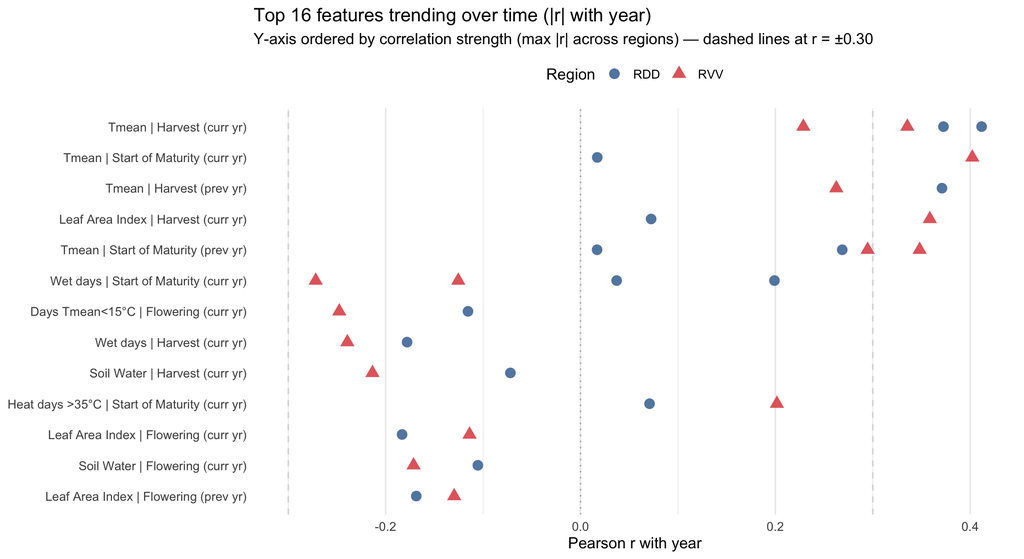

## 3.2 Time-series plots of top trending features

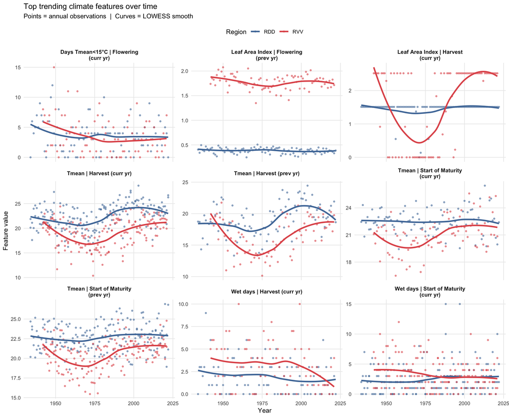

## 3.3 Interactive feature explorer

Use the slicer below to pick one or more features and see the annual series for both regions overlaid in the same chart. Useful for quickly comparing any subset of the 60 engineered features without re-running code.

> **Tip:** when comparing features with different units (e.g. Tmean in °C vs. Soil Water in mm vs. count of heat days), the y-axis scale will be dominated by the largest-magnitude one. Pick one feature at a time, or features that share units, for the cleanest read.

Pick one or more features:

[interactive chart not shown]

# 4 Feature Distributions by Decade

Decade-level violin + boxplot overlays reveal whether the **spread and shape** of a feature has changed, beyond just the mean. Widening violins suggest increasing year-to-year variability (greater climate extremes); shifts in the median line indicate directional change.

## 4.1 By phenological stage

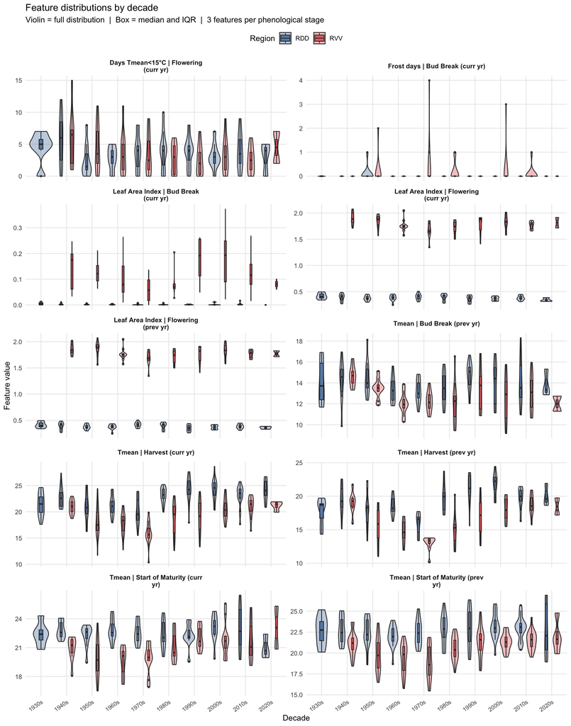

# 5 Feature–Target Correlations

## 5.1 Correlation with raw vs detrended Wine_mhl

High correlation with the **raw** target may partly reflect the shared time trend. Correlations with **detrended residuals** are more informative: they capture genuine year-to-year climate–yield relationships after accounting for the structural upward drift in production.

## 5.2 Top 20 features by correlation with detrended production

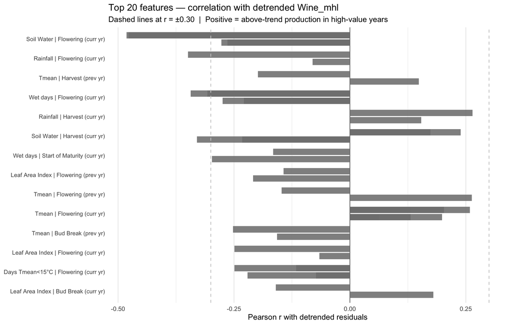

The top predictors are not identical across regions; the two stories are similar in direction but differ in which window dominates.

For **RVV** the single strongest signal in the dataset is **Soil Water at Flowering (current year)** with r ≈ −0.48, closely followed by Rainfall at Flowering (current year) at r ≈ −0.35 and Wet days at Flowering at r ≈ −0.34. The interpretation is straightforward: years with high moisture during the flowering window have below-trend production, consistent with excess moisture promoting vegetative growth, disease pressure (botrytis, downy mildew), and berry dilution that directly suppresses yield. Temperature at Flowering (current year) and Rainfall at Harvest (current year) appear with smaller positive correlations (r ≈ +0.25 and +0.27).

Combined, the regions agree on the **direction** — flowering-window moisture is broadly yield-suppressing, late-season warmth and selective harvest-window moisture are broadly yield-supporting — but they differ in which window contributes the strongest single feature. This regional asymmetry is a hint that any rule-learner will likely learn somewhat different rules in each region rather than a single shared rule set.

## 5.3 Raw vs detrended correlation comparison

Comparing the two correlation sets reveals which features were “inflated” by the shared time trend and which have genuine climate–yield signal.

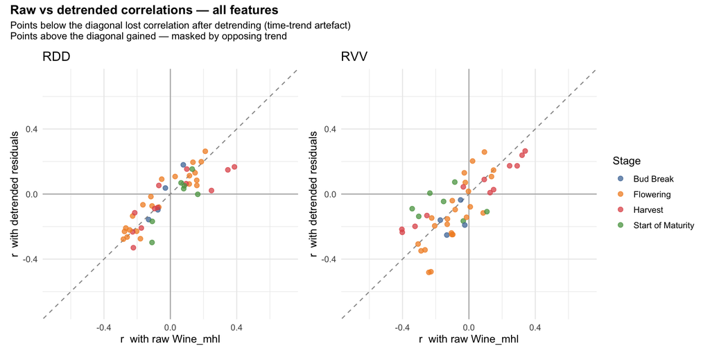

For RDD, most points cluster near or slightly below the diagonal — the raw and detrended correlations are broadly similar, which is expected since RDD’s production and most temperature features are both trending upward (a mild positive confound). For RVV the picture is more complex: production is declining while temperatures are rising, creating an implicit negative confound. Several harvest-stage temperature features (which have positive raw correlations in RDD) appear with different magnitudes after detrending in RVV, reflecting this opposing-trend effect. The net result is that the detrended correlations for RVV are less dominated by a single direction, and the genuine climate signal is more evenly distributed across stages.

## 5.4 Correlation by phenological stage

Which vine growth stage is most informative for predicting production? Stage-level aggregation gives a cleaner picture than individual features, since it averages over the quantile and window-size variants within each stage.

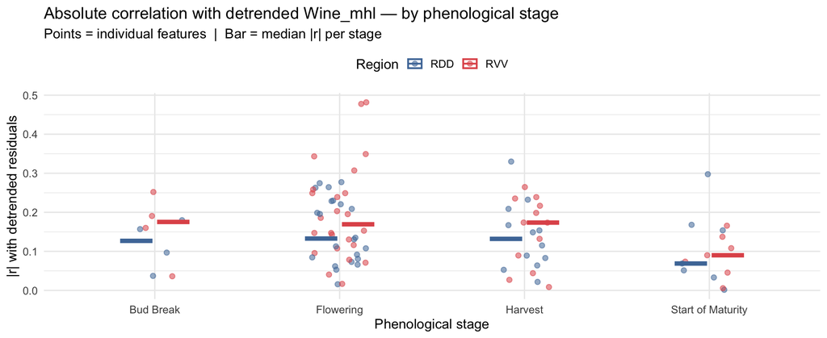

# Key Takeaways

**Production trends are opposite across regions.** RDD shows a positive long-term growth trajectory (roughly doubling from 1930s to 2000s), while RVV shows a strong negative trend — declining from over 2 000 mhl in the mid-century peak to under 900 mhl today. Both trends must be removed before modelling to isolate climate-driven variability. For RDD, a linear detrend is adequate; for RVV, LOWESS is more appropriate given the non-linear plateau-then-decline structure.

**The phenological calendar is shifting, with the late-season events shifting fastest.** All vine growth events are occurring earlier, but the rate is not uniform: Harvest moves at −0.19 d/yr (RDD) / −0.26 d/yr (RVV), Start of Maturity at −0.09 / −0.17, while Flowering and Bud Break advance roughly half as fast (−0.05 to −0.11 d/yr). The Start-of-Maturity → Harvest phase has shortened significantly in both regions, while Bud-Break → Flowering is statistically unchanged — the warming signal is concentrated in the ripening window, not the early-season one. Despite these shifts, the *timing* of events is only weakly predictive of production (|r| ≤ 0.31 across all events and regions); the informative signal lies in the climate conditions within the windows around those events.

**Flowering-window moisture is the dominant predictive signal in RVV; in RDD the harvest-window soil-water signal is comparable.** After detrending, Soil Water at Flowering (current year) is the single strongest predictor in RVV (r ≈ −0.48), with the same direction confirmed by Rainfall at Flowering and Wet days at Flowering. Excess moisture in this critical window suppresses yield through disease pressure and berry dilution. In RDD the leading single feature is Soil Water at Harvest (r ≈ −0.33), with Flowering-window moisture features slightly behind at |r| ≈ 0.27–0.30. Both regions agree on the direction (flowering moisture is yield-suppressing); they differ on which window contributes the strongest single feature.

*Generated with `eda_wine_production.Rmd`. Knit in RStudio from the project root.*